# Exploratory Data Analysis on White Wines dataset

## Bivariate Analysis

Based on the orderliness of the plots and also on the correlations (Pearson’s coefficients) with quality, we only see a few variables that are likely to have a very significant association with quality. These include *alcohol* level, *density*, *volatile acidity* level and *total SO<sub>2</sub>* level. Missing from this list is the *chlorides* level, which has a the third highest correlation coefficient association with alcohol but does not show much regularity in how its levels vary with average quality levels.

Looking a little more closely at the shape of the variable-versus-quality plots, we some possible peaks or optimal neighborhoods regarding quality. Total SO<sub>2</sub>, pH, and chlorides all have areas where quality uniformly rises and then falls, although as mentioned with chlorides this relationship may be too irregular to be important. The other variables as a whole have average quality uniformly rise or fall along with the measure of the variable in question. We found also that many variables had outliers occupying a significant portion of the plot, and compensated for this in future plots by removing the outliers.

Finally we found that the plots of *total SO<sub>2</sub>* against quality were somewhat straitened by taking the *square* of the measure of SO<sub>2</sub> level, and the corresponding plots for *volatile acidity* level were improved by taking the *log* or *square root* of the volatile acidity level.

## Multivariate Plots Section

**We now take a look how the variables we have looked at might interact in order to shape the quality.**

We ask two questions here: 1) For variables that might have an optimal level for quality, can other variables affect this optimal level? 2) Do any variables related to alcohol level moderate the effect of alcohol on quality?

**We start off taking a look at two variables that we have seen with peaks, total sulfur dioxide and pH.**

First we look at the total sulfur dioxide (SO<sub>2</sub>) We test a few variables unrelated to sulfur with moderate correlations to SO<sub>2</sub>, picking out alcohol and residual sugar.

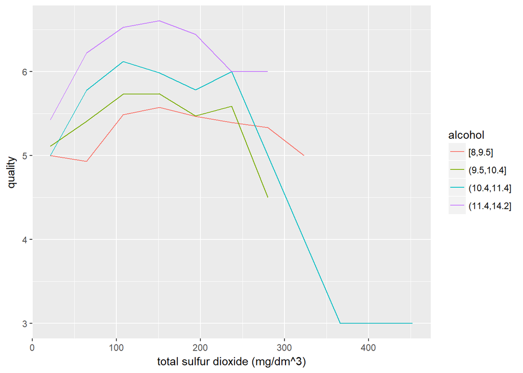

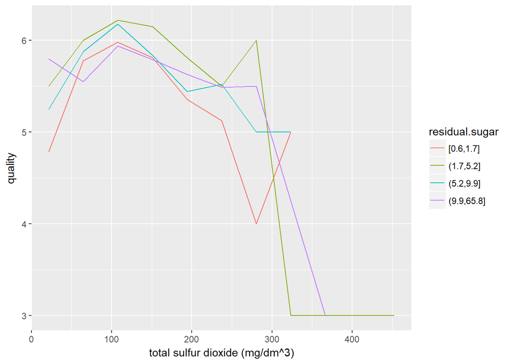

These plots are interesting, because they show what looks like a definite, nonrandom relationship between the sugar and alcohol levels and the optimum total SO<sub>2</sub> level. Each individual line which groups the sugar or alcohol levels faithfully repeats the rising then falling relationship towards quality, peaking at almost the exact same level.

Intriguingly, there are hints that alcohol level may affect the optimum total SO<sub>2</sub> point, because at higher alcohol levels the quality peaks around 150, a slightly higher SO<sub>2</sub> level than the peaks just over 100, which is the peak level overall.

Looking at the *residual sugar* level, however, shows no such effect of sugar level on the location of the peak quality. For every level of residual sugar, the peak is at exactly the same place. This reinforces the idea that there is an actual optimum level for total SO<sub>2</sub> at around 110 mg/dm<sup>3</sup> corresponding to a “sweet spot” of not too much nor too little sulfur. Indeed, all other variables (with the one exception noted below) preserved the same peak or optimum SO<sub>2</sub> level across all levels of the variable.

The one exception to this was a possible effect of *chlorides* shifting the optimal total SO<sub>2</sub> level towards 150 mg/dm<sup>3</sup> at the highest chlorides level, shown below. This could be due to higher salt levels masking the sulfur taste and smell.

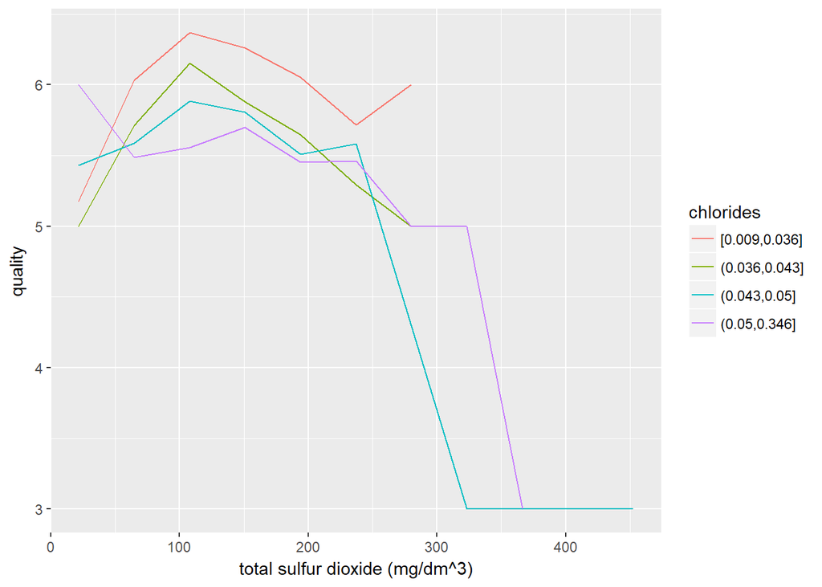

We now take a similar look at whether there is an optimal *pH* level that can be affected by other variables. But **a few plots are enough to show that there is no such well defined optimal pH level** which may or may not vary across different levels of another variable. This is illustrated by looking at *density* and *sulphates* below.

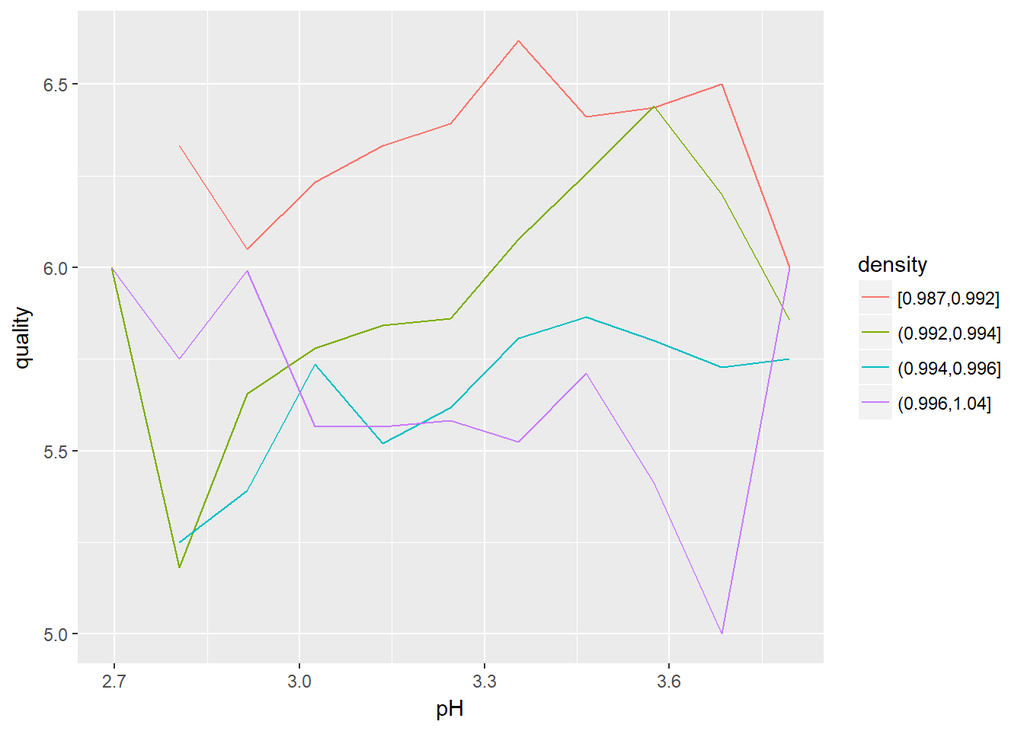

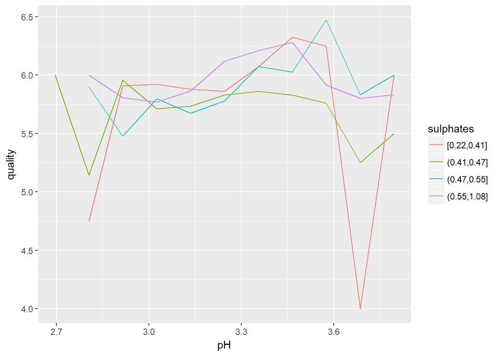

**We now take a look at the interactions of alcohol level, sugar level, and density**, as these variables are correlated and alcohol plays the largest role, as we have seen, in effecting the quality rating.

We start off taking a look *below* at the raw data points relating the three variables. This plot shows exactly the relationships posited in the initial description of the variables - higher density associated with higher sugar level but lower alcohol levels. Along a given vertical strip tracking the density level, sugar level is uniformly increasing (more red) as the density increases; likewise, we see the density decrease as the alcohol increases, as shown in the negative slope of the figure of plots taken as a whole.

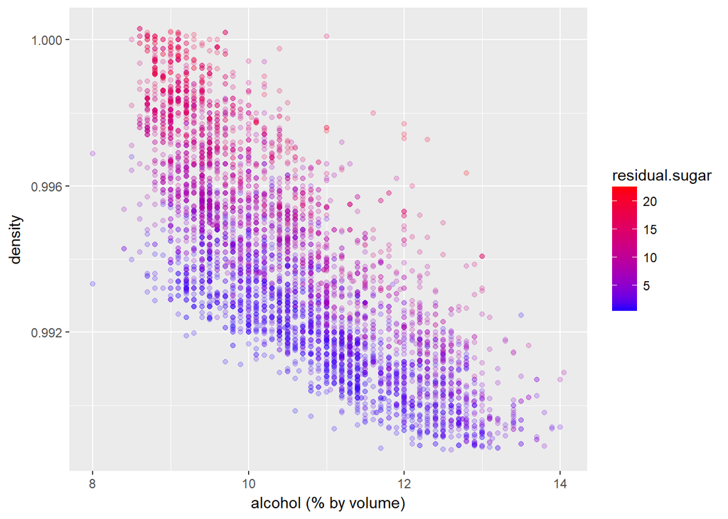

Now, we look at plots relating the variables as well as quality, starting with the below plot looking at quality versus density grouped by sugar level.

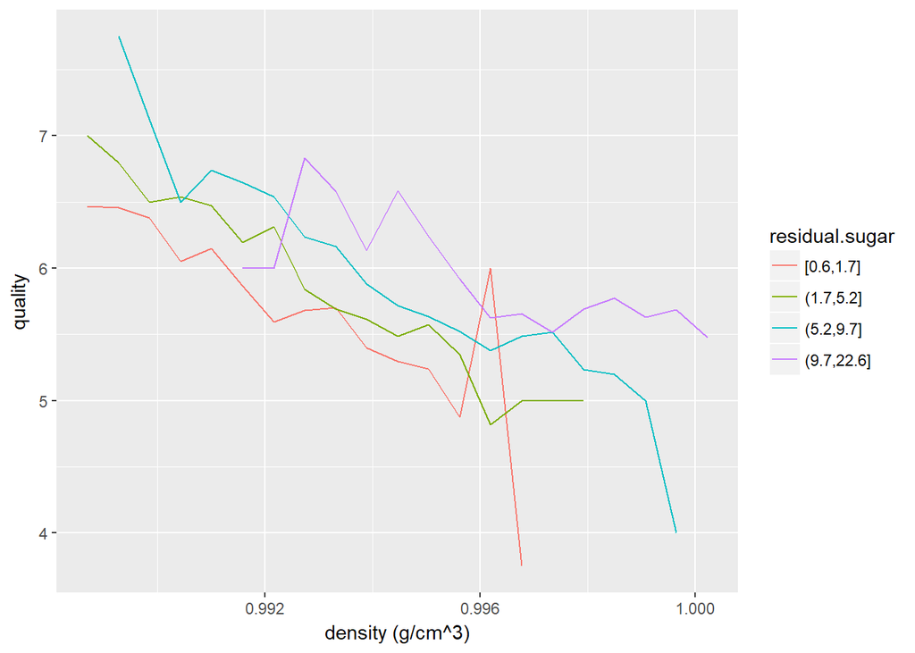

The above plot is interesting in how it shows what looks like roughly parallel lines for each group of sugar level. This seems to indicate that there is no interaction here between sugar and density in determining the quality - perhaps because only the density or only the sugar level matters.

We do a similar chart *below*, this time plotting the quality versus the alcohol level grouped by sugar level, and again see strikingly parallel lines.

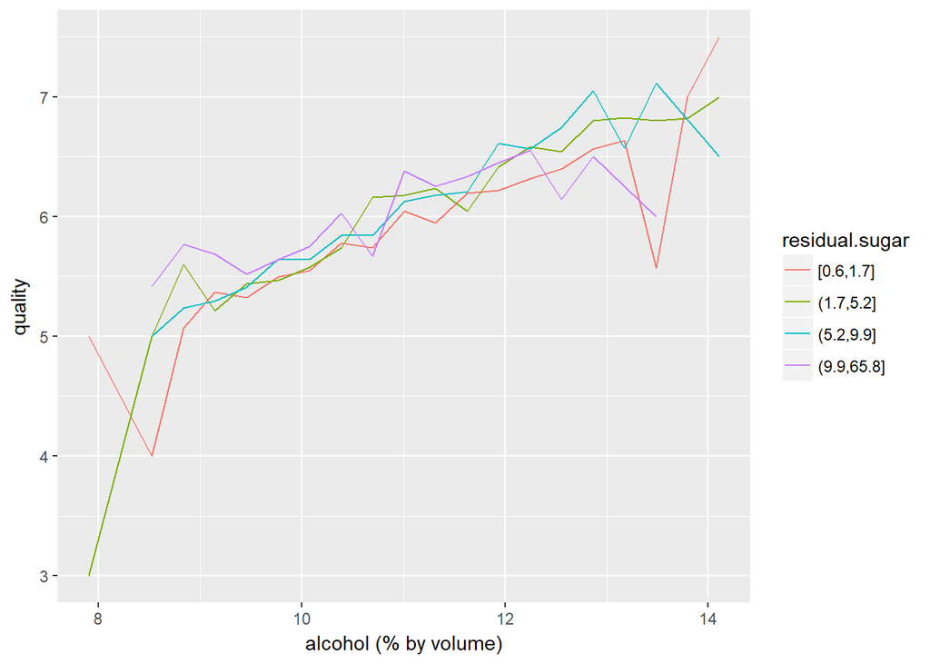

We now look at quality versus density colored by alcohol level *below*, and this time end up seeing something different that with the two previous plots.

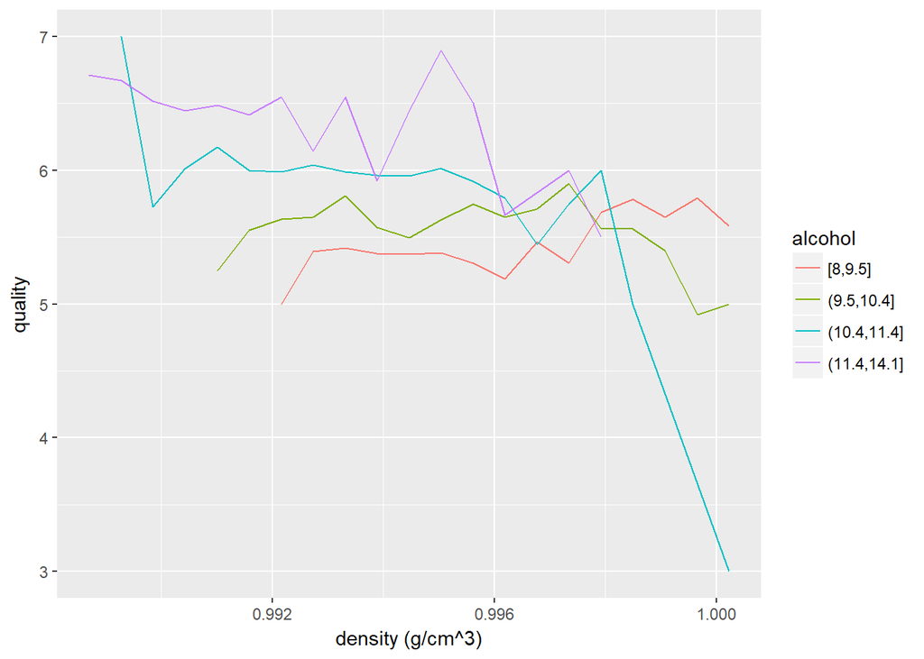

The plot above is interesting because it shows a definite change in the effect of alcohol level on quality which depends on density. It looks like there a critical density point (about .998) at which we go have the vertical order of the alcohol group lines reversing; that is, below the critical density, the the quality ordering was by increasing alcohol level, but after this density, it was by decreasing alcohol level.

So this is the opposite of the situation in the two previous charts, where we had parallel lines indicating a non-interaction of factors. Indeed we suspect now that alcohol and density interact in their effect on quality.

We see if these intuitions are still born out with the facet-based plots below. First, do we see the expected non-interactions of sugar level on the density and alcohol levels in regards to the later variables’ effect on quality? These plots are shown below.

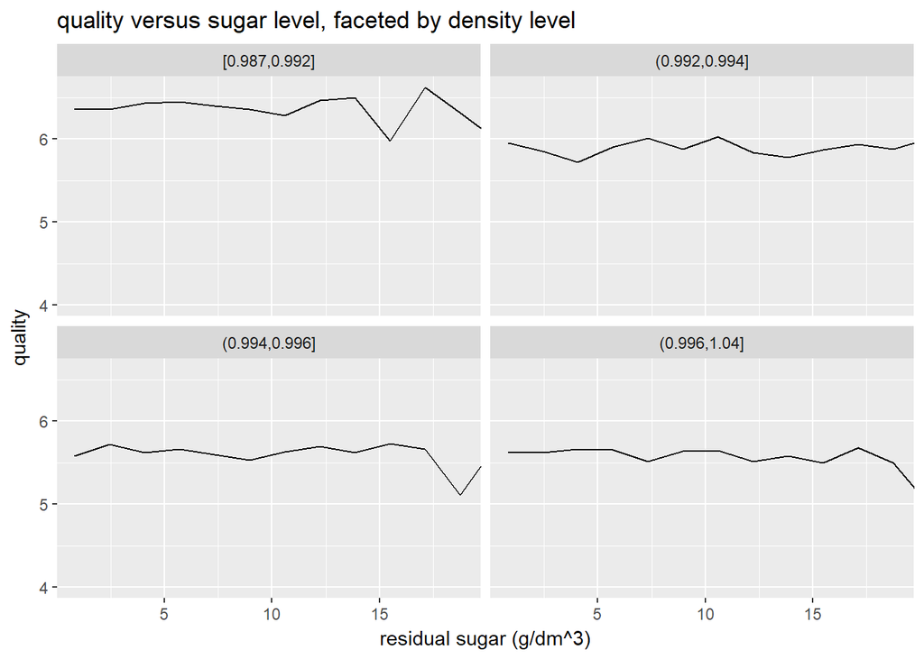

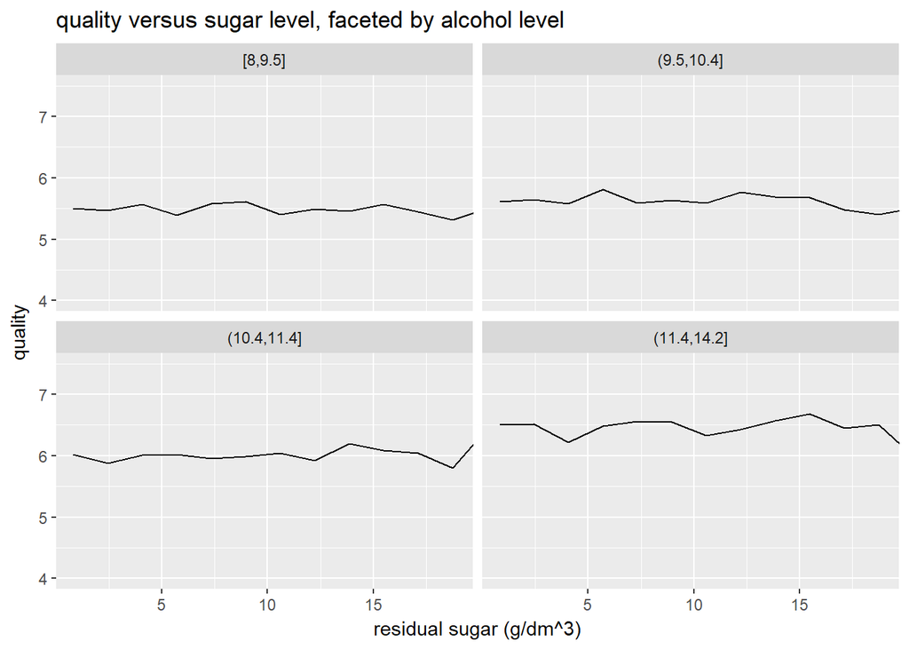

As expected, we see no interaction between sugar level and the other variables. In fact, once these variables are controlled for we see **no** effect of sugar level on density, as the plots are all flat! *So it looks like it would be safe to ignore the sugar level.*

Now we repeat with looking again at how density could affect or moderate alcohol, *below*.

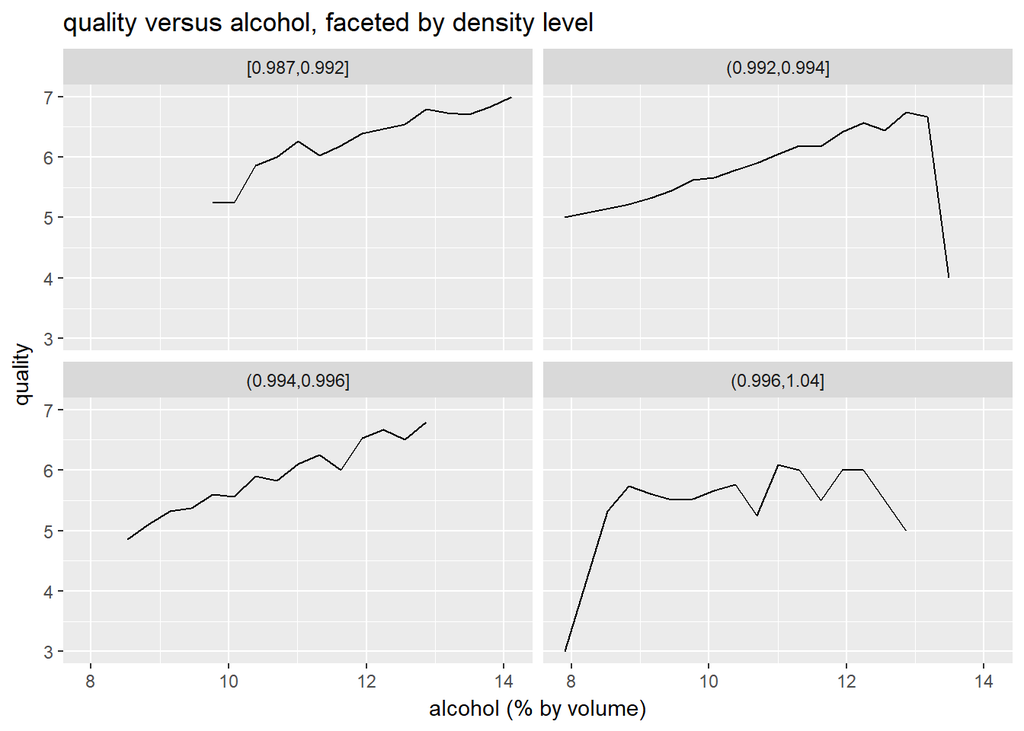

And here we see our expected interaction above. At the lower density levels, we have the typical relationship where increasing alcohol is associated with increasing quality, but at the highest density level, quality does not go up with alcohol level.

## Multivariate Analysis

We set out to see how some of the variables interacted together to help determine the quality ratings. We did this by looking at how variables affected any peak or optimal pH or total SO<sub>2</sub> measure in terms of quality rating. Is there an optimal or peak neighborhood or value, and can other variables shift this peak? We found a very well defined optimal total SO<sub>2</sub> level which appeared to be resistant to any peak shifts by other variables with the exception of alcohol level. It appeared that at higher alcohol levels, there is a peak shift or a higher optimal total SO<sub>2</sub> level. When doing the same analysis for pH, we found some hints of optimal pH but not such a well defined peak as in total SO<sub>2</sub>, and we did not see any systematic shifting of the peak by interaction with other variables.

Based on this, it would seem there is an optimal level of total SO<sub>2</sub> that reflects how a minimal amount is needed to ward off microbial growth but having too large an amount starts to affect the smell and taste. It would seem that higher alcohol level favors a higher optimal SO<sub>2</sub> level, perhaps because with more alcohol we notice the sulfur less, or perhaps we need more in order to avoid the microbial growth. In retrospect, it is not too surprising there is not *one* optimal pH level, given that there might be different wine types with their own pH profile.

We also tried to separate out the effects of alcohol, density and sugar level, as alcohol and density appear to affect quality and these three variables are all correlated. Looking closer, we saw the correlations were the predictable sort where greater density is associated with greater sugar level and lesser alcohol level. We did not see any effect of sugar level on quality after controlling for density or alcohol level, so we narrowed in on alcohol and density in the analysis. Looking further we saw that density moderates the alcohol - at higher density levels, alcohol has less an effect on quality, and in fact it goes from being positively associated (more alcohol associated with more quality) to negatively associated at a certain critical density level.

These plots looking at the different variables in combination were interesting because we could see some very well defined and tractable relationships which were just mentioned. We got a better feel for how some variables may or may not a “sweet spot” and whether this sweet spot depends on other variables. We also saw in further detail how alcohol and density played their part in helping to determine the quality level.

**We now take the intuitions gained from these investigations to see if they born out in a linear model.**

```r
> m1 <- lm(quality ~ alcohol, data = wines)
> m2 <- update(m1, ~ . + residual.sugar)
> m3 <- update(m2, ~ . + density)
> m4 <- update(m3, ~ . + total.sulfur.dioxide)
> m5 <- update(m4, ~ . + volatile.acidity )
> m6 <- update(m5, ~ . + I((volatile.acidity)^(1/2)))
> m7 <- update(m6, ~ . + I((total.sulfur.dioxide)^(2)))
> m8 <- update(m7, ~ . + pH * alcohol)
> m9 <- update(m8, ~ . + alcohol * residual.sugar * density)
> m10 <- update(m9, ~ . + pH * sulphates)
> mtable(m1, m2, m3, m4, m5)

Calls:
m1: lm(formula = quality ~ alcohol, data = wines)
m2: lm(formula = quality ~ alcohol + residual.sugar, data = wines)
m3: lm(formula = quality ~ alcohol + residual.sugar + density, data = wines)
m4: lm(formula = quality ~ alcohol + residual.sugar + density + total.sulfur.dioxide,
    data = wines)
m5: lm(formula = quality ~ alcohol + residual.sugar + density + total.sulfur.dioxide +
    volatile.acidity, data = wines)

==============================================================================================
                             m1            m2            m3            m4            m5
----------------------------------------------------------------------------------------------
  (Intercept)               2.582***      2.021***     90.313***     93.661***     82.245***
                           (0.098)       (0.117)      (12.374)      (12.665)      (12.231)
  alcohol                   0.313***      0.354***      0.246***      0.246***      0.288***
                           (0.009)       (0.010)       (0.018)       (0.018)       (0.018)
  residual.sugar                          0.022***      0.053***      0.054***      0.053***
                                         (0.002)       (0.005)       (0.005)       (0.005)
  density                                             -87.886***    -91.314***    -79.761***
                                                      (12.317)      (12.623)      (12.191)
  total.sulfur.dioxide                                                0.000         0.001**
                                                                     (0.000)       (0.000)
  volatile.acidity                                                                 -2.093***
                                                                                   (0.109)
----------------------------------------------------------------------------------------------
  R-squared                 0.190         0.202         0.210         0.210         0.265
  adj. R-squared            0.190         0.202         0.210         0.210         0.265
  sigma                     0.797         0.791         0.787         0.787         0.759
  F                      1146.395       619.354       434.085       325.984       353.570
  p                         0.000         0.000         0.000         0.000         0.000
  Log-likelihood        -5839.391     -5802.158     -5776.812     -5776.042     -5599.111
  Deviance               3112.257      3065.298      3033.737      3032.783      2821.404
  AIC                   11684.782     11612.317     11563.624     11564.084     11212.223
  BIC                   11704.272     11638.303     11596.107     11603.064     11257.699
  N                      4898          4898          4898          4898          4898
==============================================================================================
> mtable(m6, m7, m8, m9, m10)

Calls:
m6: lm(formula = quality ~ alcohol + residual.sugar + density + total.sulfur.dioxide +
    volatile.acidity + I((volatile.acidity)^(1/2)), data = wines)
m7: lm(formula = quality ~ alcohol + residual.sugar + density + total.sulfur.dioxide +
    volatile.acidity + I((volatile.acidity)^(1/2)) + I((total.sulfur.dioxide)^(2)),
    data = wines)
m8: lm(formula = quality ~ alcohol + residual.sugar + density + total.sulfur.dioxide +
    volatile.acidity + I((volatile.acidity)^(1/2)) + I((total.sulfur.dioxide)^(2)) +
    pH + alcohol:pH, data = wines)
m9: lm(formula = quality ~ alcohol + residual.sugar + density + total.sulfur.dioxide +
    volatile.acidity + I((volatile.acidity)^(1/2)) + I((total.sulfur.dioxide)^(2)) +
    pH + alcohol:pH + alcohol:residual.sugar + alcohol:density +
    residual.sugar:density + alcohol:residual.sugar:density,
    data = wines)
m10: lm(formula = quality ~ alcohol + residual.sugar + density + total.sulfur.dioxide +
    volatile.acidity + I((volatile.acidity)^(1/2)) + I((total.sulfur.dioxide)^(2)) +
    pH + sulphates + alcohol:pH + alcohol:residual.sugar + alcohol:density +
    residual.sugar:density + pH:sulphates + alcohol:residual.sugar:density,
    data = wines)

============================================================================================================
                                           m6            m7            m8            m9           m10
------------------------------------------------------------------------------------------------------------
  (Intercept)                            93.455***     94.190***    117.777***   -157.465*     -149.384*
                                        (12.383)      (12.244)      (12.573)      (70.064)      (69.745)
  alcohol                                 0.281***      0.281***     -0.922***     26.350***     28.108***
                                         (0.018)       (0.018)       (0.196)       (6.325)       (6.301)
  residual.sugar                          0.057***      0.057***      0.063***     -8.288        -7.990
                                         (0.005)       (0.005)       (0.005)       (4.513)       (4.491)
  density                               -89.738***    -91.209***   -103.692***    174.198*      169.157*
                                        (12.305)      (12.168)      (12.596)      (70.682)      (70.342)
  total.sulfur.dioxide                    0.001***      0.013***      0.012***      0.013***      0.013***
                                         (0.000)       (0.001)       (0.001)       (0.001)       (0.001)
  volatile.acidity                        2.031*        2.422**       2.093**       2.101**       2.116**
                                         (0.792)       (0.784)       (0.780)       (0.785)       (0.782)
  I((volatile.acidity)^(1/2))            -4.680***     -5.038***     -4.653***     -4.781***     -4.760***
                                         (0.890)       (0.881)       (0.876)       (0.882)       (0.878)
  I((total.sulfur.dioxide)^(2))                        -0.000***     -0.000***     -0.000***     -0.000***
                                                       (0.000)       (0.000)       (0.000)       (0.000)
  pH                                                                 -3.474***     -3.361***     -4.303***
                                                                     (0.657)       (0.670)       (0.721)
  alcohol x pH                                                        0.372***      0.362***      0.344***
                                                                     (0.062)       (0.063)       (0.063)
  alcohol x residual.sugar                                                          0.664         0.630
                                                                                   (0.391)       (0.389)
  alcohol x density                                                               -27.534***    -29.283***
                                                                                   (6.381)       (6.356)
  residual.sugar x density                                                          8.230         7.924
                                                                                   (4.524)       (4.502)
  alcohol x residual.sugar x density                                               -0.652        -0.616
                                                                                   (0.392)       (0.390)
  sulphates                                                                                      -6.470***
                                                                                                 (1.870)
  pH x sulphates                                                                                  2.210***
                                                                                                 (0.585)
------------------------------------------------------------------------------------------------------------
  R-squared                               0.270         0.286         0.296         0.302         0.309
  adj. R-squared                          0.269         0.285         0.295         0.300         0.307
  sigma                                   0.757         0.749         0.744         0.741         0.737
  F                                     300.849       279.847       228.885       162.502       145.587
  p                                       0.000         0.000         0.000         0.000         0.000
  Log-likelihood                      -5585.318     -5529.548     -5493.388     -5474.324     -5449.192
  Deviance                             2805.558      2742.390      2702.196      2681.242      2653.868
  AIC                                 11186.637     11077.095     11008.776     10978.648     10932.385
  BIC                                 11238.610     11135.565     11080.239     11076.096     11042.827
  N                                    4898          4898          4898          4898          4898
============================================================================================================
```

*The variables which were suitably transformed also were more impactful in the model in their transformed mode than in their original mode*, or at least, we needed to include the transformed mode to get any benefit from them in the model. Total sulfur was predicted to have it’s squared value proportional to quality based on the transformed plots, and in agreement with this, its squared value was also more significant than the untransformed value in the regression model, while using both the squared and untransformed terms provided the biggest benefit to the model. Similarly, volatile acidity had a more linear plot against quality after a log or square-root transformation, and these terms were also provided a bigger benefit to the regression model compared to the term for the untransformed volatile acidity value.

## Final Plots and Summary

**We now summarize some of the main findings with three plots.**

### Plot One

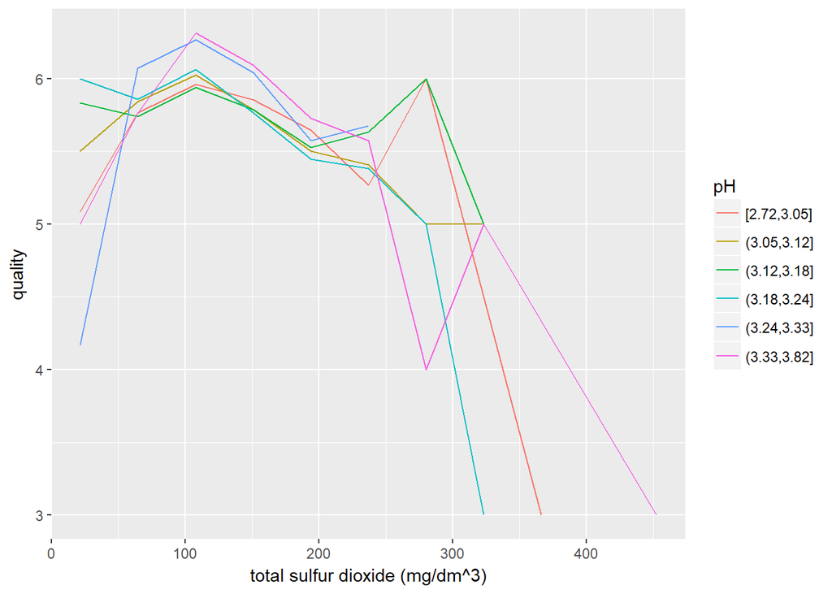

*Above*, we see a plot total SO<sub>2</sub> grouped by pH level plotted against quality. *This plot is notable because it shows a well defined an optimal point* where we have a “sweet spot” for total SO<sub>2</sub>. This is interesting because it looks like it is quite a narrow region of SO<sub>2</sub> level, and moreover it appears to be **totally unaffected by the pH level.** Despite the lack of solid predictors for quality besides alcohol level (based on Pearson’s correlation coefficient), we apparently have a very solid relationship between the total SO<sub>2</sub> and quality, because there is no other way to explain the orderliness in this plot.

### Plot Two

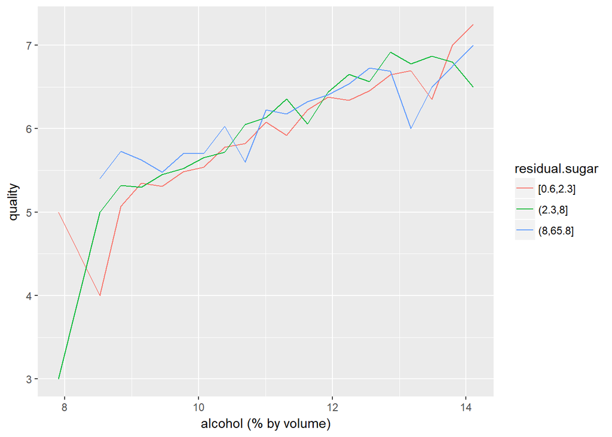

*Next we see a very orderly relationship, but of a different nature*. This *above* is a plot of the relationship of quality to the alcohol level grouped by the (residual) sugar level. It is notable how parallel the colored lines are, reflecting a lack of effect of sugar level on the effect that alcohol has on the quality. This was born out with other plots shown earlier in which we see no effect of sugar level on quality when you control for the alcohol level.

### Plot Three

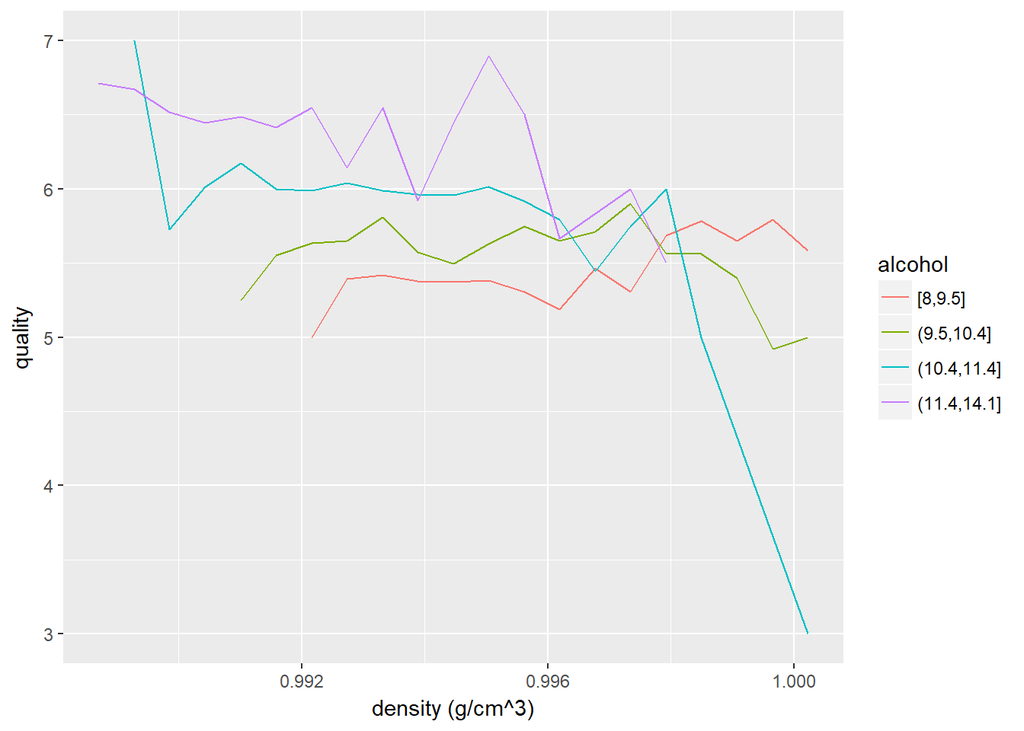

*And finally we do see a significant interaction here among the variables affecting quality.* Below a density level of about .998, we have increases in quality ratings associated with *increases* in alcohol levels, whereas above this density, increases in quality are associated with *decreasing* alcohol levels.

**To summarize, we do see some very solid, tractable relationships of some variables to the quality ratings.** Given this, it is somewhat surprising that we do not get many variables with stronger correlations to quality, or an effective linear regression model using these relationships and interactions.

## Reflections

The most encouraging result of this investigation was that we were able to verify that there were nontrivial, tractable relationships between some of the variables analyzed and the quality, in spite of the rather meek correlation coefficients associated with the quality ratings. We saw regular, predictable line plots in some cases when plotting the variables’ levels against average quality, and this persisted in some cases even when grouping by other variables.  
Also, we were able to get some “straitened” plots of some variables by transforming with square, square root, or log transformations, and these turned out to be as or more important than their untransformed measures in the linear model we created.

There were some definite limitations to these investigations. We could not show any tractable, predictable trend of chlorine level versus quality, despite the chlorine level having the third highest (Pearson’s) correlation with quality. Also, the linear model as a whole was not terribly useful aside from verifying a few intuitions, as it had a very low R<sup>2</sup> amount of variance in quality explained by the model.

One potential improvement to the dataset would have been to use something like wine *types*, such as white zinfandel. It is possible that the physical variables can only have so much explanatory power, given that there could in theory be a different physical profile (say, higher or lower pH or alcohol content) of some wine types. **Or perhaps, as the saying goes, “There is no accounting for taste!”**